# Datacamp ggplot2 - Part 2 CHIS Exercise

Chinpei Tang

In this chapter we’re going to continuously build on our plotting functions and understanding to produce a mosaic plot (aka Merimeko plot). This is a visual representation of a contingency table, comparing two categorical variables. Essentially, our question is which groups are over or under represented in our dataset. To visualize this we’ll color groups according to their pearson residuals from a chi-squared test. At the end of it all we’ll wrap up our script into a flexible function so that we can look at other variables.

We’ll familiarize ourselves with a small number of variables from the 2009 CHIS adult-response dataset (as opposed to children). The data can be found at: http://healthpolicy.ucla.edu/chis/data/Pages/GetCHISData.aspx. The Datacamp has selected the following variables to explore:

- RBMI: BMI Category description
- BMI_P: BMI value
- RACEHPR2: race
- SRSEX: sex
- SRAGE_P: age
- MARIT2: Marital status
- AB1: General Health Condition
- ASTCUR: Current Asthma Status
- AB51: Type I or Type II Diabetes
- POVLL: Poverty level

Since Datacamp loads the data in the background on the tutorial portal, in order to do it externally, the data is downloaded and imported with the following commands. It is saved to the RData file. This codes are not executed here since it takes some times to run.

```r
if(F){
  library(foreign)
  adult <- read.spss("ADULT.sav", to.data.frame = T)
  save(adult, file = "CHIS_adult.RData")
}
```

We load some of the other libraries. Since the data imported doesn’t look exactly the same from Datacamp, some work were done to mimic the data from Datacamp in order to do the exercises.

```r
library(ggplot2)
library(reshape2) # for melt() function
library(dplyr)
library(ggthemes)
library(car)
# Load the saved RData file
load(file = "C:/Users/Chinpei/Documents/R/CHIS/chis09_adult_spss/chis09_adult_spss/CHIS_adult.RData")

# Some manipulations to make data "looks like" form Datacamp
adult <- adult[c("RBMI", "BMI_P", "RACEHPR2", "SRSEX", "SRAGE_P", "MARIT2", "AB1", "ASTCUR", "AB51", "POVLL")]
adult$RACEHPR2 <- factor(adult$RACEHPR2, levels = c("LATINO", "ASIAN", "AFRICAN AMERICAN", "WHITE"), labels = c(1, 4, 5, 6))
adult$RBMI <- factor(adult$RBMI, levels = c("UNDERWEIGHT 0-18.49", "NORMAL 18.5-24.99", "OVERWEIGHT 25.0-29.99", "OBESE 30.0+"), labels = c(1, 2, 3, 4))
```

We’ll filter our dataset to plot a more reliable subset (we’ll still retain over 95% of the data).

Before we get into mosaic plots it’s worthwhile exploring the dataset using simple distribution plots - i.e. histograms.

# Exploring Data

Use the typical commands for exploring the structure of adult to get familiar with the variables: summary() and str().

```r
# Explore the dataset with summary and str
summary(adult)
```

```
##  RBMI          BMI_P       RACEHPR2        SRSEX          SRAGE_P
##  1: 1068   Min.   :12.65   1   : 5753   MALE  :19428   Min.   :18.00
##  2:19831   1st Qu.:22.82   4   : 4874   FEMALE:28186   1st Qu.:44.00
##  3:16152   Median :25.74   5   : 1950                  Median :57.00
##  4:10563   Mean   :26.73   6   :31769                  Mean   :55.67
##            3rd Qu.:29.43   NA's: 3268                  3rd Qu.:69.00
##            Max.   :93.72                               Max.   :85.00
##
##                MARIT2                   AB1
##  NOT ASCERTAINED  :    0   VERY GOOD      :15490
##  MARRIED          :24936   GOOD           :13658
##  LIVING W/ PARTNER: 2336   EXCELLENT      : 9114
##  WID/SEP/DIV      :13360   FAIR           : 6878
##  NEVER MARRIED    : 6982   POOR           : 2474
##                            NOT ASCERTAINED:    0
##                            (Other)        :    0
##                ASTCUR                   AB51
##  NOT ASCERTAINED  :    0   NOT ASCERTAINED:    0
##  CURRENT ASTHMA   : 4120   DON'T KNOW     :    0
##  NO CURRENT ASTHMA:43494   REFUSED        :    0
##                            INAPPLICABLE   :42796
##                            TYPE I         :  512
##                            TYPE 2         : 4206
##                            ANOTHER TYPE   :  100
##                 POVLL
##  0-99% FPL         : 5764
##  100-199% FPL      : 8026
##  200-299% FPL      : 6532
##  300% FPL AND ABOVE:27292
##
##
##
```

```r
str(adult)
```

```
## 'data.frame':    47614 obs. of  10 variables:
##  $ RBMI    : Factor w/ 4 levels "1","2","3","4": 3 3 3 2 3 4 2 3 2 3 ...
##  $ BMI_P   : atomic  28.9 26.1 25.1 25 25.1 ...
##   ..- attr(*, "value.labels")= Named num -9
##   .. ..- attr(*, "names")= chr "NOT ASCERTAINED"
##  $ RACEHPR2: Factor w/ 4 levels "1","4","5","6": 4 4 4 4 4 4 NA 4 4 4 ...
##  $ SRSEX   : Factor w/ 2 levels "MALE","FEMALE": 1 2 1 1 1 2 2 1 2 1 ...
##  $ SRAGE_P : num  32 80 71 39 75 53 67 42 33 67 ...
##  $ MARIT2  : Factor w/ 5 levels "NOT ASCERTAINED",..: 2 4 2 5 2 2 2 2 2 4 ...
##  $ AB1     : Factor w/ 9 levels "NOT ASCERTAINED",..: 5 5 6 5 6 7 6 6 6 5 ...
##  $ ASTCUR  : Factor w/ 3 levels "NOT ASCERTAINED",..: 3 3 2 3 3 2 3 3 3 3 ...
##  $ AB51    : Factor w/ 7 levels "NOT ASCERTAINED",..: 4 4 4 4 4 4 4 4 4 4 ...
##  $ POVLL   : Factor w/ 4 levels "0-99% FPL","100-199% FPL",..: 4 4 4 4 4 4 4 4 3 4 ...
```

As a first exploration of the data, plot two histograms using ggplot2 syntax: one for age (SRAGE_P) and one for BMI (BMI_P). The goal is to explore the dataset and get familiar with the distributions here. Feel free to explore different bin widths. We’ll ask some questions about these in the next exercises.

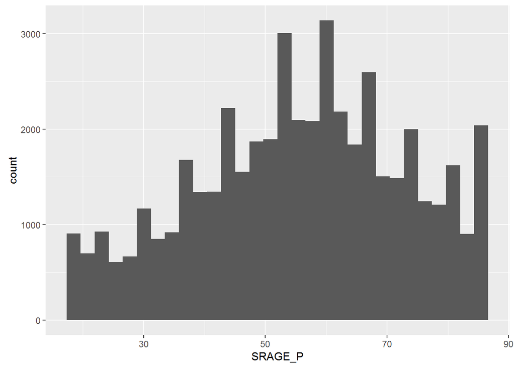

```r
# Age histogram
ggplot(adult, aes(x = SRAGE_P)) +
  geom_histogram()
```

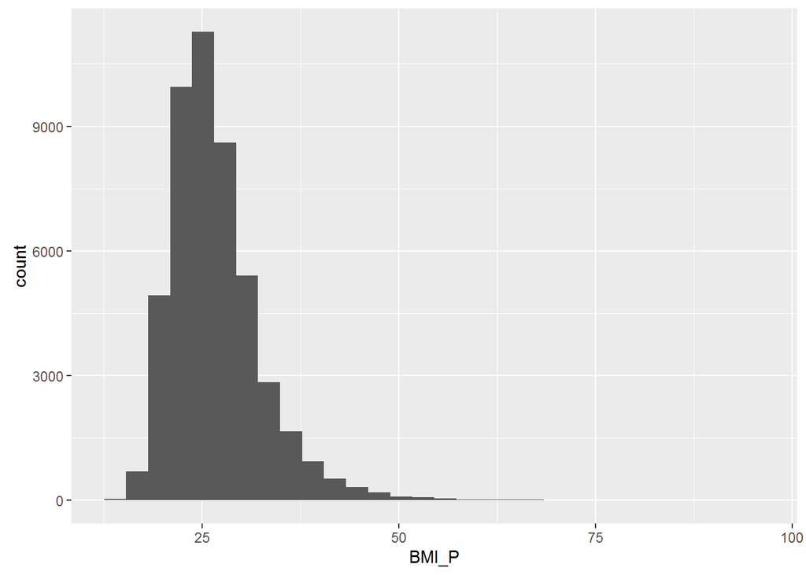

```r
# BMI histogram
ggplot(adult, aes(x = BMI_P)) +
  geom_histogram()
```

Next plot a binned-distribution of age, filling each bar according to the BMI categorization. Inside geom_histogram(), set binwidth = 1. You’ll want to use factor() to map RBMI as a categorical variable.

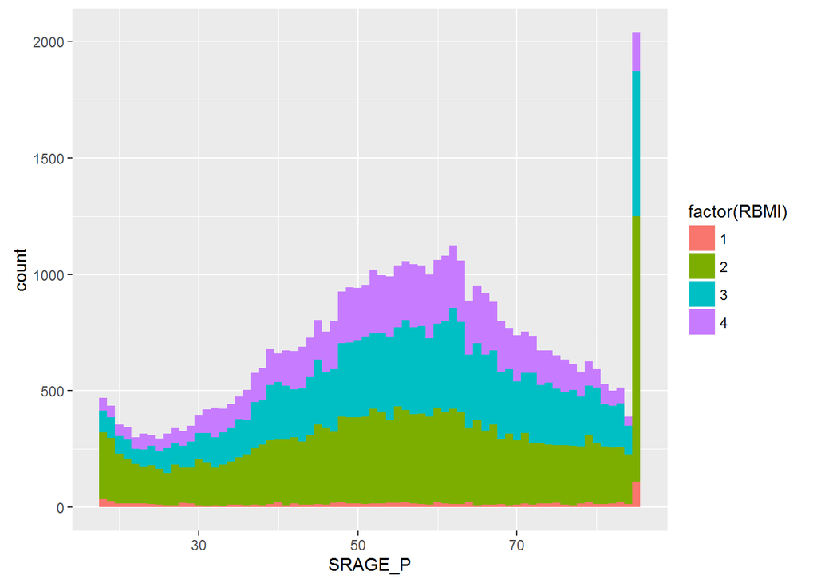

```r
# Age colored by BMI, default binwidth
ggplot(adult, aes(x = SRAGE_P, fill = factor(RBMI))) +
  geom_histogram(binwidth = 1)
```